# Visualizing the reporting lines of the IAM Manager

*David Doret*

*Version 1.1*

*May 2020*

## In a nutshell

This R notebook uses an Euler chart to visualize the reporting lines of IAM managers.

## Introduction

As part of the *IAM Performance Measurement 2020 Survey*, I surveyed IAM professionals about the reporting lines IAM managers in their organization. In this data analysis notebook, I use R to analyse and visualize the answers to this question.

The original survey question #22 was:

> To whom reports the IAM manager in your organization?

The non-exclusive possible answers were:

- CFO
- CISO
- CIO
- COO
- CEO
- Other
- I don’t know

When the survey participant selected the **Other* option, he could type in the other function name. In this notebook, I will *not* analyse the answers provided in free text form.

## Setting up the technical environment

To conduct this data analysis, we first need to setup our technical environment.

```r
# Set console to English
Sys.setenv(LANG = "en");

# Install R packages as needed
if(!require("eulerr")) install.packages("eulerr");
if(!require("tidyr")) install.packages("tidyr");
if(!require("RCurl")) install.packages("RCurl");
if(!require("plyr")) install.packages("plyr");
if(!require("knitr")) install.packages("knitr");

# Load libraries
library(eulerr);
library(tidyr);
library(RCurl);
library(plyr);
library(knitr);
```

## Retrieve the data

Then we need to load the survey data. In accordance with the *Open Source* and *Open Data* spirit of the *Open-Measure* project, all data is publicly available on GitHub.

```r
# Configuration options
survey_url = "https://raw.githubusercontent.com/Open-Measure/Open-Data/master/IAMPerf2020-Dataset/IAMPerf2020.csv";
question_number = 22;

# Download the survey data from GitHub
survey_raw <- RCurl::getURL(survey_url);

# Interpret the CSV to get structured data
survey_data <- read.csv (text = survey_raw);

# In the original survey data,
# we are interested in question 22: Reporting line of the line manager.
# The column names corresponding to the question options are prefixed with Q22.
# The column names of the options ("CFO", "CISO", ...) are suffixed with Ax.
# Here is the mapping table:
# Q22A1: CFO
# Q22A2: CISO
# Q22A3: CIO
# Q22A4: COO
# Q22A5: CEO
# Q22A6: Other
# Q22A7: I don't know

# Pick only the columns we are interested in,
# and rename columns to friendly names in the process.
question_data = data.frame(
  CFO = survey_data$Q22A1,
  CISO = survey_data$Q22A2,
  CIO = survey_data$Q22A3,
  COO = survey_data$Q22A4,
  CEO = survey_data$Q22A5,
  Other = survey_data$Q22A6
);

# Note: in the survey data, column Q22A7 is the "I don't know" option.
# We discard it here on purpose as "NA".

knitr::kable(head(question_data))
```

| CFO | CISO | CIO | COO | CEO | Other |
| --- | --- | --- | --- | --- | --- |
| NA | 1 | NA | NA | NA | NA |
| NA | NA | NA | NA | NA | NA |
| NA | NA | NA | NA | NA | NA |
| NA | NA | NA | NA | NA | 1 |
| NA | 1 | NA | NA | NA | 1 |
| NA | 1 | 1 | NA | NA | NA |

As we can see, we have a table structure with one row per survey answer and one column per selectable option. When the option was selected by the participant, it takes value 1 and N/A otherwise.

Note that options are not exclusive. In consequence we may find both single-valued answers and multi-valued answers.

## Basic counting

Let’s count how many times every option was selected, independently on whether the options come from single-valued answers or multi-valued answers.

```r
# Some basic stats.
n = nrow(question_data)

# We may use the sum function because a selected option correspond to a value of 1.
option_count = c(
  CFO = sum(!is.na(question_data$CFO)),
  CISO = sum(!is.na(question_data$CISO)),
  CIO = sum(!is.na(question_data$CIO)),
  COO = sum(!is.na(question_data$COO)),
  CEO = sum(!is.na(question_data$CEO)),
  Other = sum(!is.na(question_data$Other))
  );

knitr::kable(data.frame(t(sort(option_count, decreasing = TRUE))));
```

| CISO | CIO | Other | COO | CEO | CFO |
| --- | --- | --- | --- | --- | --- |
| 42 | 15 | 13 | 7 | 2 | 0 |

We immediately spot the high frequency of the CISO reporting line, followed by the CIO.

## Introducing the Euler chart

We could stop the analysis here and output a bar or pie chart but this would hide an interesting aspect of our data: multi-valued answers. To overcome this limitation, we will use a different visualization: an **Euler chart**. This visualization will show the relative importance of individual options by the size of its bubbles but will also display the multi-valued answers as interesections between bubbles.

To do this, we should count every *unique* combination of selected options.

```r
# The question options in the survey are non-exclusive,
# thus we need to keep track of all combinations (e.g. CISO + CIO).
# What we really need is to count both multiple value answers (e.g. CISO + CIO)
# and and single value answers (e.g. CISO).
# To accomplish this, reduce the table to its unique row combinations (e.g. CISO + CIO).
# And count the occurrences of these combinations.
# The plyr count function does all of this in a single shot,
# and appends the freq column (# of occurences).
question_flat = data.frame(plyr::count(question_data));

# Basic stats.
answered = sum(question_flat$freq[question_flat$option_count != 0]);
unanswered = sum(question_flat$freq[question_flat$option_count == 0]);

knitr::kable(question_flat[order(question_flat$freq, decreasing = TRUE),]);
```

|  | CFO | CISO | CIO | COO | CEO | Other | freq |
| --- | --- | --- | --- | --- | --- | --- | --- |
| 9 | NA | NA | NA | NA | NA | NA | 129 |
| 3 | NA | 1 | NA | NA | NA | NA | 36 |
| 8 | NA | NA | NA | NA | NA | 1 | 11 |
| 5 | NA | NA | 1 | NA | NA | NA | 10 |
| 6 | NA | NA | NA | 1 | NA | NA | 6 |
| 1 | NA | 1 | 1 | NA | NA | NA | 4 |
| 2 | NA | 1 | NA | NA | NA | 1 | 2 |
| 7 | NA | NA | NA | NA | 1 | NA | 2 |
| 4 | NA | NA | 1 | 1 | NA | NA | 1 |

```r
NA
```

## Labeling

In our Euler graph, we wish to label bubbles with the title of the selected options, but we will not label intersections. In effect, intersections are self-explanatory (this is the whole visual value of Euler graphs). But to generate the Euler graph, we still need to keep track of these intersections.

So let’s label our data.

```r
# Count the number of selected options per answer (ie row).
# This will help us distinguish between single-valued and multi-valued answers.
# We couldn't sum directly all columns because the freq column is now present.
question_flat$option_count =
  tidyr::replace_na(question_flat$CFO, 0) +
  tidyr::replace_na(question_flat$CISO, 0) +
  tidyr::replace_na(question_flat$CIO, 0) +
  tidyr::replace_na(question_flat$COO, 0) +
  tidyr::replace_na(question_flat$CEO, 0) +
  tidyr::replace_na(question_flat$Other, 0);

# To facilitate concatenation, prepare columns with strings.
question_flat$CFO_text = ifelse(question_flat$CFO == 1, "CFO", NA);
question_flat$CISO_text = ifelse(question_flat$CISO == 1, "CISO", NA);
question_flat$CIO_text = ifelse(question_flat$CIO == 1, "CIO", NA);
question_flat$COO_text = ifelse(question_flat$COO == 1, "COO", NA);
question_flat$CEO_text = ifelse(question_flat$CEO == 1, "CEO", NA);
question_flat$Other_text = ifelse(question_flat$Other == 1, "Other", NA);

# Declare a utility function to perform the paste operation
# on a vector (here it will be rows) while discarding NAs in the process.
get_technical_label = function(some_vector, sep = "") {
  some_vector = some_vector[!is.na(some_vector)];
  some_vector = base::paste(some_vector, collapse = sep);
  return(some_vector);
};

# Multi-value concatenations.
# The euler uses a naming convention
# where bubble names are listed and separated by "&", e.g. "A&B",
# to designate set intersections.
question_flat$technical_label = apply(
  question_flat[,c("CFO_text","CISO_text","CIO_text","COO_text","CEO_text","Other_text")],
  1,
  get_technical_label, "&");

# To populate human friendly readable labels, we only keep the single-valued ones.
question_flat$friendly_label = ifelse(
  question_flat$option_count == 1,
  question_flat$technical_label, # A single-valued label.
  "" # A blank label.
  );

# All this work to get this simple representation:
knitr::kable(question_flat[order(question_flat$freq, decreasing = TRUE),][,c("technical_label", "friendly_label", "freq")]);
```

|  | technical_label | friendly_label | freq |
| --- | --- | --- | --- |
| 9 |  |  | 129 |
| 3 | CISO | CISO | 36 |
| 8 | Other | Other | 11 |
| 5 | CIO | CIO | 10 |
| 6 | COO | COO | 6 |
| 1 | CISO&CIO |  | 4 |
| 2 | CISO&Other |  | 2 |
| 7 | CEO | CEO | 2 |
| 4 | CIO&COO |  | 1 |

```r
NA
```

## Plotting

And finally, we may plot the Euler chart.

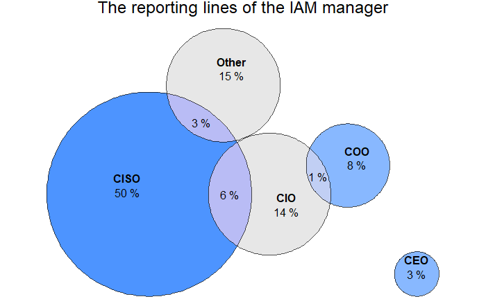

```r
# Remove entries with no selected option
euler_data = question_flat$freq[question_flat$option_count != 0];
names(euler_data) = question_flat$technical_label[question_flat$option_count != 0];
euler_labels = question_flat$friendly_label[question_flat$option_count != 0];

# Keep a basic sample handily available to see how intersections are accounted for
# because we do not want to double-count entries.
# euler_data = c(100, 100, 100)
# names(euler_data) = c("A", "A&B", "B")

# Transform our data in the object class required by the eulerr package.
eulerr_object = eulerr::euler(euler_data)

# Some branding
palette = c("#0066ff", "#dddddd", "#dddddd", "#5599ff", "#5599ff");

# And now we may draw our Euler chart
plot(
  eulerr_object,
  #labels = euler_labels,
  fills = palette,
  edges = TRUE,
  quantities = list(fontsize = 24, cex = .5, type = "percent"),
  alpha = 0.7,
  main = "The reporting lines of the IAM manager"
  );
```

## Percentages per function

```r
answered
```

[output not shown]

## Sample and answer rate

And finally we should accompany the graph with information on the sample and answer rate.

```r
# Prepare a legend to inform on the sample size and answer rate.
legend_block = paste(
  "n: ", n,
  ", answered: ", answered, " (", round(answered / n * 100), "%)",
  ", unanswered:", unanswered, " (", round(unanswered / n * 100), "%)",
  sep = "");

print(legend_block)
```

[output not shown]

# References

- https://cran.r-project.org/web/packages/eulerr/vignettes/visualization.html
- https://stackoverflow.com/questions/46044564/customizing-euler-diagram-colors-with-eulerr-r